# 1. Business Understanding

- How to make a next step towards earning extra money with your property?
- What attributes increase my Airbnb listing price?
- What attributes decrease my Airbnb listing price?
- How to maximize my Airbnb profits?

# 2. Data Understanding

```python
import numpy as np
import pandas as pd
import matplotlib.pyplot as plt
import seaborn as sns
from itertools import chain
from sklearn.model_selection import train_test_split
from sklearn.linear_model import LinearRegression
from sklearn.metrics import r2_score, mean_squared_error
%matplotlib inline
```

```python
df = pd.read_csv("data/listings.csv")
```

## Inspection of the data set

Before we start changing the data set, we have to go column after column and investigate the data types, irrelevant columns and duplicates. To achieve this, we used the following methods. Below we show only the investigating methods for one column exemplary.

The most important part of the data analysis is to achieve an understanding about data we have. To get a high validity of data, we first have to check, if the **data types** are correct. Often number are stored as strings not as numerical data types. To have a correct data types for the analysis, we have to convert the data types, often using regular expressions. Second, **irrelevant data** and **duplicates** have to be removed. Third, we have to investigate **missing data**.

```python
df["security_deposit"].shape[0] #Provide the number of rows in the column
df["security_deposit"].dtypes #Provide the data type of the column
df["security_deposit"].isnull().sum() #Count empty entries within the column
df["security_deposit"].describe() #Show simple statistics of the column
df["security_deposit"].unique() #Show variables stored in the column
df["security_deposit"].head(5) #Show first entries of the column
```

```
0          NaN
1      $100.00
2    $1,000.00
3          NaN
4      $700.00
Name: security_deposit, dtype: object
```

Source: https://towardsdatascience.com/the-ultimate-guide-to-data-cleaning-3969843991d4

## Cleaning the data set from irrelevant data and duplicates.

After we inspected our data set by looking into 92 columns, we have to drop irrelevant data:

- all url columns, which does not help us with the analysis and contain no relevant information
- all ids, description, irrelevant columns or duplicates
- all information which does not improve the analysis like city, state etc.

```python
to_drop =[#Drop all url columns, which does not help us with the analysis and contain no relevant information.
            "listing_url",
            "thumbnail_url",
            "medium_url",
            "picture_url",
            "xl_picture_url",
            "host_url",
            "host_thumbnail_url",
            "host_picture_url",
            #Drop all ids.
            "id",
            "scrape_id",
            "host_id",
            #Drop all descriptions.
            "name",
            "summary",
            "description",
            "space",
            "neighborhood_overview",
            "host_about",
            "notes",
            "transit",
            #Drop irrelevant columns, or columns with no data
            "host_name",
            "host_location",
            "host_neighbourhood",
            "host_verifications",
            "last_scraped",
            "calendar_last_scraped",
            #future data irrelevant for the past
            "has_availability",
            "availability_30",
            "availability_60",
            "availability_90",
            "availability_365",
            "requires_license",
            #drop information about the past, since we will not investigate it
            "host_since",
            "first_review",
            "last_review",
            #Drop duplicates: weekly and monthly price. We are only interested in general price
            "weekly_price",
            "monthly_price",
            #Drop empty columns with empty values
            "experiences_offered",
            #Drop redudant information (similar to host_response_rate)
            "host_response_time",
            #Drop redudant information (similar to review_scores_location)

            #Drop redudant information (similar to neighbourhood_group_cleansed)
            "neighbourhood_cleansed",
            "neighbourhood",
            "street",
            #Drop host_listing variables, as calculated_host_listings_count is more accurate
            "host_listings_count",
            "host_total_listings_count",
            #Drop information which does not improve the analysis
            "city",
            "state",
            "zipcode",
            "market",
            "smart_location",
            "country_code",
            "country",
            "jurisdiction_names",
            "calendar_updated",
            "latitude",
            "longitude"
        ]
```

```python
df = df.drop(columns=to_drop, axis=1)
```

## Converting data types from objects to correct ones.

In the second step we transform the object data types. Unfortunately while reading the csv-file, the correct data types was not recognized. Using regular expressions, we transform the string objects, so that we can convert the data to correct types.

### Covert to a boolean

```python
df=df.replace(to_replace=["t", "f","nan"], value=[1, 0, np.nan])
```

### Convert to float

```python
perc_to_float = ["host_response_rate","host_acceptance_rate"]
df[perc_to_float] = df[perc_to_float].replace(regex=["%"], value="").astype(np.float16) / 100.0
```

### Remove commas and dollars signs from the columns and convert to float

```python
to_float = ["price",
            "security_deposit",
            "cleaning_fee",
            "extra_people"]
df[to_float] = df[to_float].replace({
                                    "\$": "",
                                     ",": ""}, regex=True)
df[to_float]=df[to_float].astype(np.float)
```

### Convert to integer

```python
df=df.dropna(subset=["host_has_profile_pic"])
df=df.dropna(subset=["host_is_superhost"])
to_int = [
        "host_is_superhost",
        "host_has_profile_pic",
        "host_identity_verified",
        "instant_bookable",
        "require_guest_profile_picture",
        "require_guest_phone_verification",
        "is_location_exact"
            ]
df[to_int]=df[to_int].astype(np.int)
```

### Show categorical data.

```python
df_categorical = list(df.select_dtypes(include=['object']).columns)
```

### Amenities Encoding

Unfortunately amenities are saved as a json, but read_csv recognizes only a string. In the first step we will split the string in parts and using regular expressions we will remove unnecessary characters. Then we will encode amenities as dummy variables

```python
amenities = df["amenities"].str.split(",",expand=True)
amenities.head(3)
```

|  | 0 | 1 | 2 | 3 | 4 | 5 | 6 | 7 | 8 | 9 | ... | 20 | 21 | 22 | 23 | 24 | 25 | 26 | 27 | 28 | 29 |
| --- | --- | --- | --- | --- | --- | --- | --- | --- | --- | --- | --- | --- | --- | --- | --- | --- | --- | --- | --- | --- | --- |
| 0 | {TV | "Cable TV" | Internet | "Wireless Internet" | "Air Conditioning" | Kitchen | Heating | "Family/Kid Friendly" | Washer | Dryer} | ... | None | None | None | None | None | None | None | None | None | None |
| 1 | {TV | Internet | "Wireless Internet" | Kitchen | "Free Parking on Premises" | "Buzzer/Wireless Intercom" | Heating | "Family/Kid Friendly" | Washer | Dryer | ... | None | None | None | None | None | None | None | None | None | None |
| 2 | {TV | "Cable TV" | Internet | "Wireless Internet" | "Air Conditioning" | Kitchen | "Free Parking on Premises" | "Pets Allowed" | "Pets live on this property" | Dog(s) | ... | Shampoo} | None | None | None | None | None | None | None | None | None |

3 rows × 30 columns

```python
amenities = amenities.replace(regex=["[^\w\s]"], value="")
```

```python
amenities_list = [amenities[item].unique().tolist() for item in amenities.columns.values]
amenities_list = set(list(chain.from_iterable(amenities_list)))
amenities_list.remove('')
amenities_list.remove(None)
amenities_list
```

```
{'24Hour Checkin',
 'Air Conditioning',
 'Breakfast',
 'BuzzerWireless Intercom',
 'Cable TV',
 'Carbon Monoxide Detector',
 'Cats',
 'Dogs',
 'Doorman',
 'Dryer',
 'Elevator in Building',
 'Essentials',
 'FamilyKid Friendly',
 'Fire Extinguisher',
 'First Aid Kit',
 'Free Parking on Premises',
 'Gym',
 'Hair Dryer',
 'Hangers',
 'Heating',
 'Hot Tub',
 'Indoor Fireplace',
 'Internet',
 'Iron',
 'Kitchen',
 'Laptop Friendly Workspace',
 'Lock on Bedroom Door',
 'Other pets',
 'Pets Allowed',
 'Pets live on this property',
 'Pool',
 'Safety Card',
 'Shampoo',
 'Smoke Detector',
 'Smoking Allowed',
 'Suitable for Events',
 'TV',
 'Washer',
 'Washer  Dryer',
 'Wheelchair Accessible',
 'Wireless Internet'}
```

```python
for items in amenities_list:
    df[items] = df["amenities"].apply(lambda x: 1 if items in x else 0)
```

```python
df.drop(columns="amenities",inplace=True)
```

### Drop empty aminities

```python
drop_0 = [
            "Other pets",
            "Washer  Dryer",
            "Cats",
            "Dogs",
            "24Hour Checkin",
            "BuzzerWireless Intercom",
            "FamilyKid Friendly"
            ]
```

```python
df = df.drop(columns=drop_0, axis=1)
```

## Analyze missing data

```python
 #Provide a set of columns with 0 missing values.
no_nulls = set(df.columns[df.isnull().mean() == 0])
print(no_nulls)
```

```
{'Wheelchair Accessible', 'host_is_superhost', 'cancellation_policy', 'Lock on Bedroom Door', 'room_type', 'Washer', 'accommodates', 'Free Parking on Premises', 'Indoor Fireplace', 'Doorman', 'Smoke Detector', 'Dryer', 'Shampoo', 'is_location_exact', 'require_guest_profile_picture', 'Carbon Monoxide…
```

```python
drop_75 = [col for col in df.columns if df[col].isnull().sum()/  df.shape[0] > 0.75]
drop_75
```

```
['square_feet', 'license']
```

### Drop columns with more than 75 % empty values

```python
df = df.drop(columns=drop_75, axis=1)
```

### Fill missing data with entries

```python
nan_to_zero = ["security_deposit","cleaning_fee"]
df[nan_to_zero]=df[nan_to_zero].fillna(0)
```

### Investigate missing data

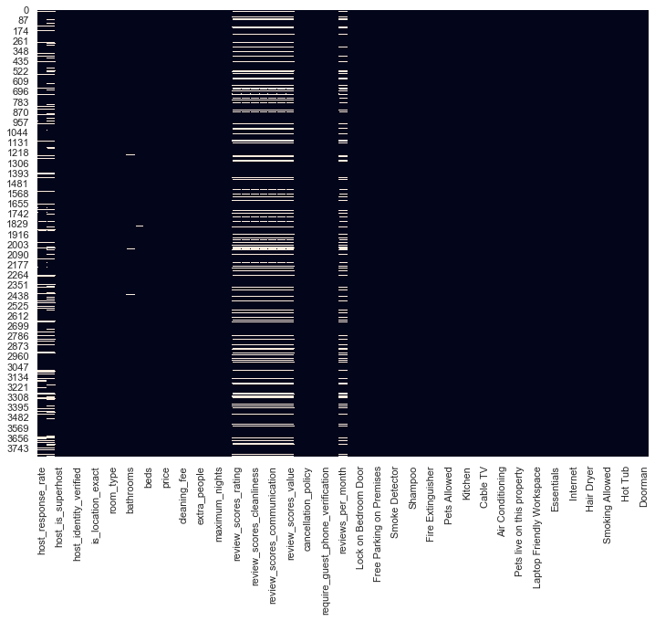

```python
plt.figure(figsize=(12, 9))
sns.heatmap(df.isnull(), cbar=False)
```

## Analyze Data

```python
df["price_per_person"] = (df["price"]+ df["cleaning_fee"])/ df["accommodates"]
df["price_per_person"].fillna(0, inplace = True)
```

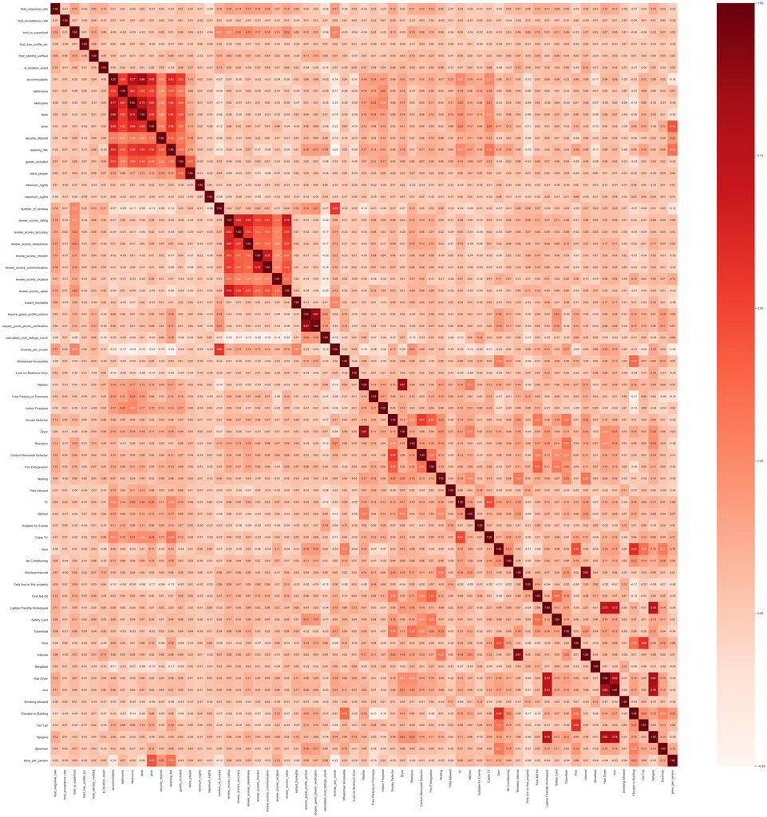

```python
plt.figure(figsize=(50,50))
cor = df.corr()
sns.heatmap(cor, annot=True, cmap=plt.cm.Reds, fmt=".2f")
plt.show()
```

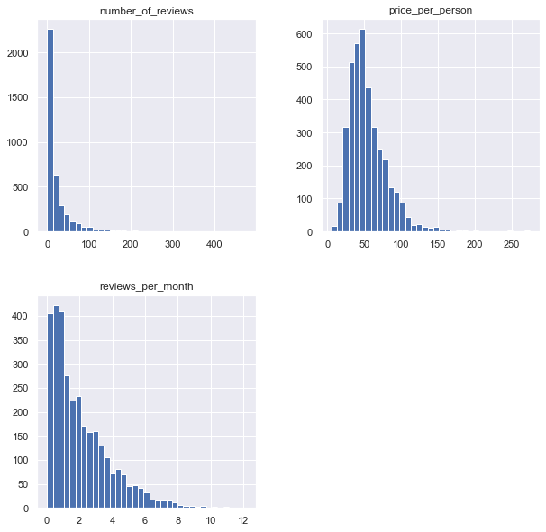

```python
hist = df.hist(column=["reviews_per_month","number_of_reviews","price_per_person"], figsize=(10,10), bins=35)
```

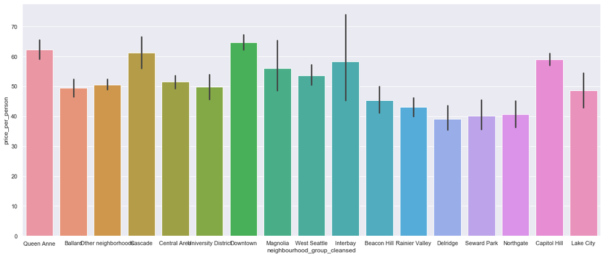

```python
import seaborn as sns
%matplotlib inline
sns.set(rc={'figure.figsize':(20,8.27)})
sns.barplot(x="neighbourhood_group_cleansed",y="price_per_person",data=df)
```

```python
#Correlation with output variable
cor_Y = cor["price_per_person"]
#Showing all correlated features
cor_Y.sort_values(ascending=False)
```

```
price_per_person                    1.000000
price                               0.454125
cleaning_fee                        0.350421
security_deposit                    0.203517
Elevator in Building                0.198643
Doorman                             0.121563
review_scores_location              0.121196
Gym                                 0.120789
Cable TV                            0.113371
calculated_host_listings_count      0.083392
Pool                                0.083153
require_guest_profile_picture       0.077501
Air Conditioning                    0.076503
TV                                  0.075863
Kitchen                             0.071869
require_guest_phone_verification    0.069068
bathrooms                           0.067893
Hot Tub                             0.060124
review_scores_rating                0.057456
review_scores_cleanliness           0.047834
extra_people                        0.043730
host_is_superhost                   0.033979
Washer                              0.033724
is_location_exact                   0.030891
Wheelchair Accessible               0.030126
Suitable for Events                 0.027487
Dryer                               0.027284
review_scores_accuracy              0.025629
host_identity_verified              0.018371
Indoor Fireplace                    0.016748
                                      ...
bedrooms                           -0.004667
Carbon Monoxide Detector           -0.006559
maximum_nights                     -0.008081
host_has_profile_pic               -0.016607
guests_included                    -0.020732
host_response_rate                 -0.022906
Fire Extinguisher                  -0.023408
Heating                            -0.023520
review_scores_checkin              -0.029164
Iron                               -0.030975
review_scores_communication        -0.031730
First Aid Kit                      -0.032686
review_scores_value                -0.034253
Smoking Allowed                    -0.036158
Laptop Friendly Workspace          -0.039142
Breakfast                          -0.040326
Lock on Bedroom Door               -0.041744
Essentials                         -0.042807
Hair Dryer                         -0.043097
Pets Allowed                       -0.044563
Hangers                            -0.046562
Smoke Detector                     -0.049897
Shampoo                            -0.058516
instant_bookable                   -0.063909
Pets live on this property         -0.078505
beds                               -0.087425
Free Parking on Premises           -0.098190
number_of_reviews                  -0.121019
accommodates                       -0.159946
reviews_per_month                  -0.219961
Name: price_per_person, Length: 65, dtype: float64
```

# 3. Prepare Data

```python
def create_cat_encodings(dataframe, categorical_list, dummy_na):
    '''
    Convert categorical variables into dummy variables.

    INPUT:
    dataframe - input dataframe
    categorical_list - list of categorical variables
    dummy_na - add a column to indicate NaNs, if False NaNs are ignored.

    OUTPUT:
    dataframe - a new dataframe, that contains all previous columns except the categoricals,
    '''
    dummies =pd.get_dummies(dataframe[categorical_list],drop_first=True,dummy_na=dummy_na)
    dataframe = pd.concat([dataframe.drop(categorical_list,axis=1), dummies], axis=1, join='inner')

    return dataframe
```

```python
df_categorical = list(df.select_dtypes(include=['object']).columns)
df_extended = create_cat_encodings (df,df_categorical, dummy_na=False )
```

```python
df_extended.head()
```

|  | host_response_rate | host_acceptance_rate | host_is_superhost | host_has_profile_pic | host_identity_verified | is_location_exact | accommodates | bathrooms | bedrooms | beds | ... | property_type_Treehouse | property_type_Yurt | room_type_Private room | room_type_Shared room | bed_type_Couch | bed_type_Futon | bed_type_Pull-out Sofa | bed_type_Real Bed | cancellation_policy_moderate | cancellation_policy_strict |
| --- | --- | --- | --- | --- | --- | --- | --- | --- | --- | --- | --- | --- | --- | --- | --- | --- | --- | --- | --- | --- | --- |
| 0 | 0.959961 | 1.0 | 0 | 1 | 1 | 1 | 4 | 1.0 | 1.0 | 1.0 | ... | 0 | 0 | 0 | 0 | 0 | 0 | 0 | 1 | 1 | 0 |
| 1 | 0.979980 | 1.0 | 1 | 1 | 1 | 1 | 4 | 1.0 | 1.0 | 1.0 | ... | 0 | 0 | 0 | 0 | 0 | 0 | 0 | 1 | 0 | 1 |
| 2 | 0.669922 | 1.0 | 0 | 1 | 1 | 1 | 11 | 4.5 | 5.0 | 7.0 | ... | 0 | 0 | 0 | 0 | 0 | 0 | 0 | 1 | 0 | 1 |
| 3 | NaN | NaN | 0 | 1 | 1 | 1 | 3 | 1.0 | 0.0 | 2.0 | ... | 0 | 0 | 0 | 0 | 0 | 0 | 0 | 1 | 0 | 0 |
| 4 | 1.000000 | NaN | 0 | 1 | 1 | 1 | 6 | 2.0 | 3.0 | 3.0 | ... | 0 | 0 | 0 | 0 | 0 | 0 | 0 | 1 | 0 | 1 |

5 rows × 104 columns

### Select highly correlated features with price per person

```python
cor = df_extended.corr()
cor_Y = cor["price_per_person"]
cor_Y.sort_values(ascending=False)
```

```
price_per_person                                    1.000000
price                                               0.454125
cleaning_fee                                        0.350421
security_deposit                                    0.203517
Elevator in Building                                0.198643
neighbourhood_group_cleansed_Downtown               0.162595
cancellation_policy_strict                          0.130720
Doorman                                             0.121563
review_scores_location                              0.121196
Gym                                                 0.120789
Cable TV                                            0.113371
neighbourhood_group_cleansed_Queen Anne             0.090053
calculated_host_listings_count                      0.083392
Pool                                                0.083153
property_type_Boat                                  0.079727
neighbourhood_group_cleansed_Capitol Hill           0.078682
require_guest_profile_picture                       0.077501
Air Conditioning                                    0.076503
TV                                                  0.075863
Kitchen                                             0.071869
require_guest_phone_verification                    0.069068
bathrooms                                           0.067893
bed_type_Real Bed                                   0.063524
Hot Tub                                             0.060124
review_scores_rating                                0.057456
property_type_Condominium                           0.051757
review_scores_cleanliness                           0.047834
extra_people                                        0.043730
neighbourhood_group_cleansed_Cascade                0.042380
property_type_Bed & Breakfast                       0.039962
                                                      ...
Smoking Allowed                                    -0.036158
bed_type_Pull-out Sofa                             -0.038353
Laptop Friendly Workspace                          -0.039142
Breakfast                                          -0.040326
room_type_Shared room                              -0.040489
cancellation_policy_moderate                       -0.041405
Lock on Bedroom Door                               -0.041744
bed_type_Futon                                     -0.042067
Essentials                                         -0.042807
property_type_Dorm                                 -0.042850
Hair Dryer                                         -0.043097
Pets Allowed                                       -0.044563
Hangers                                            -0.046562
Smoke Detector                                     -0.049897
neighbourhood_group_cleansed_Seward Park           -0.057727
Shampoo                                            -0.058516
neighbourhood_group_cleansed_Beacon Hill           -0.059966
instant_bookable                                   -0.063909
neighbourhood_group_cleansed_Other neighborhoods   -0.070834
neighbourhood_group_cleansed_Northgate             -0.075342
Pets live on this property                         -0.078505
neighbourhood_group_cleansed_Delridge              -0.083484
beds                                               -0.087425
neighbourhood_group_cleansed_Rainier Valley        -0.088460
Free Parking on Premises                           -0.098190
number_of_reviews                                  -0.121019
property_type_House                                -0.126896
accommodates                                       -0.159946
room_type_Private room                             -0.168101
reviews_per_month                                  -0.219961
Name: price_per_person, Length: 104, dtype: float64
```

# 4. Data Modeling

### Fill all missing values with 0

```python
df_extended = df_extended.fillna(0)
df_extended.isnull().count().mean() == df_extended.shape[0]
df_extended.head()
```

|  | host_response_rate | host_acceptance_rate | host_is_superhost | host_has_profile_pic | host_identity_verified | is_location_exact | accommodates | bathrooms | bedrooms | beds | ... | property_type_Treehouse | property_type_Yurt | room_type_Private room | room_type_Shared room | bed_type_Couch | bed_type_Futon | bed_type_Pull-out Sofa | bed_type_Real Bed | cancellation_policy_moderate | cancellation_policy_strict |
| --- | --- | --- | --- | --- | --- | --- | --- | --- | --- | --- | --- | --- | --- | --- | --- | --- | --- | --- | --- | --- | --- |
| 0 | 0.959961 | 1.0 | 0 | 1 | 1 | 1 | 4 | 1.0 | 1.0 | 1.0 | ... | 0 | 0 | 0 | 0 | 0 | 0 | 0 | 1 | 1 | 0 |
| 1 | 0.979980 | 1.0 | 1 | 1 | 1 | 1 | 4 | 1.0 | 1.0 | 1.0 | ... | 0 | 0 | 0 | 0 | 0 | 0 | 0 | 1 | 0 | 1 |
| 2 | 0.669922 | 1.0 | 0 | 1 | 1 | 1 | 11 | 4.5 | 5.0 | 7.0 | ... | 0 | 0 | 0 | 0 | 0 | 0 | 0 | 1 | 0 | 1 |
| 3 | 0.000000 | 0.0 | 0 | 1 | 1 | 1 | 3 | 1.0 | 0.0 | 2.0 | ... | 0 | 0 | 0 | 0 | 0 | 0 | 0 | 1 | 0 | 0 |
| 4 | 1.000000 | 0.0 | 0 | 1 | 1 | 1 | 6 | 2.0 | 3.0 | 3.0 | ... | 0 | 0 | 0 | 0 | 0 | 0 | 0 | 1 | 0 | 1 |

5 rows × 104 columns

### Create X and y data sets for the model. After that split the data into training and testing data set.

```python
#create X and y data set
df_categorical = list(df_extended.select_dtypes(include=['object']).columns)
df_new = df_extended.drop(columns=df_categorical)
df_new = df_extended
# df_new = df_new.fillna(0)
y  = df_new["price_per_person"]
X  = df_new.drop(columns=["price_per_person","price","accommodates","cleaning_fee"], axis=0)
```

```python
#split into training and test sets
X_train, X_test, y_train, y_test = train_test_split(X,
                                                    y,
                                                    test_size=0.30,
                                                    random_state=42)
```

```python
#fit and transform training data
from sklearn.preprocessing import StandardScaler
scaler=StandardScaler()
X_train_imp=scaler.fit_transform(X_train)

#transform test data
X_test_imp=scaler.transform(X_test)
```

### Instantiate and fit the LR Model

```python
lm_model = LinearRegression(normalize=True) # Instantiate
lm_model.fit(X_train_imp, y_train) #Fit

#Predict using your model
y_test_preds = lm_model.predict(X_test_imp)
y_train_preds = lm_model.predict(X_train_imp)

#Score using your model
test_score = r2_score(y_test, y_test_preds)
train_score = r2_score(y_train, y_train_preds)
```

# 5. Evaluate the Results

```python
#Print training and testing score
print("The rsquared on the training data was {}.  The rsquared on the test data was {}.".format(train_score, test_score))
```

```
The rsquared on the training data was 0.3038236069286634.  The rsquared on the test data was 0.2605096588046998.
```

```python
#extract coefficients
feature_importances = pd.DataFrame(lm_model.coef_,
                                   index = X_train.columns,
                                    columns=["coefficient"]).sort_values("coefficient", ascending=False)
```

```python
feature_importances
```

|  | coefficient |
| --- | --- |
| review_scores_location | 7.544330 |
| review_scores_rating | 6.475103 |
| security_deposit | 3.576273 |
| Elevator in Building | 3.324963 |
| calculated_host_listings_count | 3.315824 |
| host_is_superhost | 2.994642 |
| neighbourhood_group_cleansed_Downtown | 2.496304 |
| review_scores_cleanliness | 2.323117 |
| review_scores_accuracy | 2.194100 |
| bathrooms | 2.192843 |
| cancellation_policy_strict | 2.147447 |
| property_type_Boat | 2.080549 |
| bedrooms | 1.770069 |
| Dryer | 1.764811 |
| property_type_House | 1.750359 |
| Cable TV | 1.734323 |
| neighbourhood_group_cleansed_Queen Anne | 1.684141 |
| is_location_exact | 1.587605 |
| neighbourhood_group_cleansed_Capitol Hill | 1.557012 |
| cancellation_policy_moderate | 1.442020 |
| property_type_Loft | 1.435507 |
| First Aid Kit | 1.418802 |
| extra_people | 1.270648 |
| Indoor Fireplace | 1.197013 |
| property_type_Townhouse | 1.148427 |
| property_type_Bed & Breakfast | 1.127077 |
| Hot Tub | 0.934668 |
| Wireless Internet | 0.881583 |
| Suitable for Events | 0.763465 |
| property_type_Bungalow | 0.670478 |
| ... | ... |
| Gym | -0.644510 |
| host_response_rate | -0.713641 |
| Wheelchair Accessible | -0.731218 |
| Pool | -0.748613 |
| neighbourhood_group_cleansed_Other neighborhoods | -0.823905 |
| property_type_Tent | -0.879996 |
| maximum_nights | -0.917630 |
| Heating | -0.924868 |
| Smoke Detector | -0.992063 |
| Pets Allowed | -0.996075 |
| neighbourhood_group_cleansed_Rainier Valley | -1.056265 |
| bed_type_Pull-out Sofa | -1.182675 |
| neighbourhood_group_cleansed_Seward Park | -1.330456 |
| TV | -1.383315 |
| bed_type_Futon | -1.446032 |
| neighbourhood_group_cleansed_University District | -1.518379 |
| Hangers | -1.558251 |
| neighbourhood_group_cleansed_Northgate | -1.559431 |
| neighbourhood_group_cleansed_Delridge | -1.573123 |
| bed_type_Real Bed | -1.591788 |
| Washer | -1.648584 |
| guests_included | -1.731221 |
| room_type_Shared room | -3.533984 |
| host_acceptance_rate | -3.802856 |
| reviews_per_month | -4.261347 |
| review_scores_value | -5.165779 |
| room_type_Private room | -5.511402 |
| review_scores_communication | -6.060912 |
| review_scores_checkin | -6.756385 |
| beds | -8.177140 |

100 rows × 1 columns